# funModeling quick-start

Pablo Casas

2018-01-16

# funModeling quick-start

This package contains a set of functions related to exploratory data analysis, data preparation, and model performance. It is used by people coming from business, research, and teaching (professors and students).

`funModeling` is intimately related to the *Data Science Live Book* -Open Source- (2017) in the sense that most of its functionality is used to explain different topics addressed by the book.

[figure not shown]

Data Science Live Book

## Opening the black-box

Some functions have in-line comments so the user can open the black-box and learn how it was developed, or to tune or improve any of them.

All the functions are well documented, explaining all the parameters with the help of many short examples. R documentation can be accessed by: `help("name_of_the_function")`.

This quick-start is focused only on the functions. All explanations around them, and the how and when to use them, can be accessed by following the “**Read more here.**” links below each section, which redirect you to the book.

## Exploratory data analysis

### `df_status`: Dataset health status

Use case: analyze the zeros, missing values (`NA`), infinity, data type, and number of unique values for a given dataset.

```r
library(funModeling)

df_status(heart_disease)
```

```
##                  variable q_zeros p_zeros q_na p_na q_inf p_inf    type
## 1                     age       0       0    0 0.00     0     0 integer
## 2                  gender       0       0    0 0.00     0     0  factor
## 3              chest_pain       0       0    0 0.00     0     0  factor
## 4  resting_blood_pressure       0       0    0 0.00     0     0 integer
## 5       serum_cholestoral       0       0    0 0.00     0     0 integer
## 6     fasting_blood_sugar     258      85    0 0.00     0     0  factor
## 7         resting_electro     151      50    0 0.00     0     0  factor
## 8          max_heart_rate       0       0    0 0.00     0     0 integer
## 9             exer_angina     204      67    0 0.00     0     0 integer
## 10                oldpeak      99      33    0 0.00     0     0 numeric
## 11                  slope       0       0    0 0.00     0     0 integer
## 12      num_vessels_flour     176      58    4 1.32     0     0 integer
## 13                   thal       0       0    2 0.66     0     0  factor
## 14 heart_disease_severity     164      54    0 0.00     0     0 integer
```

[output cut: 21 more lines]

🔎 [**Read more here.**](https://livebook.datascienceheroes.com/exploratory-data-analysis.html#dataset-health-status)

### `plot_num`: Plotting distributions for numerical variables

Plots only numeric variables.

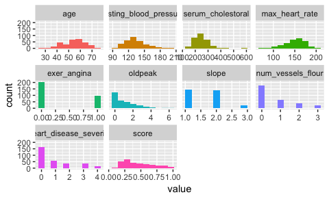

```r
plot_num(heart_disease)
```

Notes:

- `bins`: Sets the number of bins (10 by default).
- `path_out` indicates the path directory; if it has a value, then the plot is exported in jpeg.

🔎 [**Read more here.**](https://livebook.datascienceheroes.com/exploratory-data-analysis.html#plotting-numerical-variable)

### `profiling_num`: Calculating several statistics for numerical variables

Retrieves several statistics for numerical variables.

```r
profiling_num(heart_disease)
```

```
##                  variable   mean std_dev variation_coef   p_01   p_05
## 1                     age  54.44    9.04           0.17  35.00  40.00
## 2  resting_blood_pressure 131.69   17.60           0.13 100.00 108.00
## 3       serum_cholestoral 246.69   51.78           0.21 149.00 175.10
## 4          max_heart_rate 149.61   22.88           0.15  95.02 108.10
## 5             exer_angina   0.33    0.47           1.44   0.00   0.00
## 6                 oldpeak   1.04    1.16           1.12   0.00   0.00
## 7                   slope   1.60    0.62           0.38   1.00   1.00
## 8       num_vessels_flour   0.67    0.94           1.39   0.00   0.00
## 9  heart_disease_severity   0.94    1.23           1.31   0.00   0.00
## 10                  score   0.46    0.23           0.49   0.15   0.18
##      p_25  p_50   p_75   p_95   p_99 skewness kurtosis   iqr
## 1   48.00  56.0  61.00  68.00  71.00    -0.21      2.5 13.00
## 2  120.00 130.0 140.00 160.00 180.00     0.70      3.8 20.00
## 3  211.00 241.0 275.00 326.90 406.74     1.13      7.4 64.00
```

[output cut: 18 more lines]

Note:

- `plot_num` and `profiling_num` automatically exclude non-numeric variables

🔎 [**Read more here.**](https://livebook.datascienceheroes.com/exploratory-data-analysis.html#numerical-profiling-in-r)

### `freq`: Getting frequency distributions for categoric variables

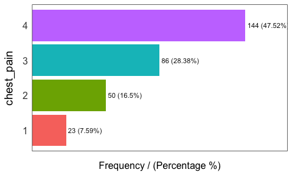

```
##   chest_pain frequency percentage cumulative_perc
## 1          4       144       47.5              48
## 2          3        86       28.4              76
## 3          2        50       16.5              92
## 4          1        23        7.6             100
```

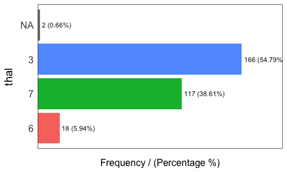

```
##   thal frequency percentage cumulative_perc
## 1    3       166      54.79              55
## 2    7       117      38.61              93
## 3    6        18       5.94              99
## 4 <NA>         2       0.66             100
```

```
## [1] "Variables processed: chest_pain, thal"
```

```r
library(dplyr)

# Select only two variables for this example
heart_disease_2=heart_disease %>% select(chest_pain, thal)

# Frequency distribution
freq(heart_disease_2)
```

Notes:

- `freq` only processes `factor` and `character`, excluding non-categorical variables.
- It returns the distribution table as a data frame.
- If `input` is empty, then it runs for all categorical variables.
- `path_out` indicates the path directory; if it has a value, then the plot is exported in jpeg.
- `na.rm` indicates if `NA` values should be excluded (`FALSE` by default).

🔎 [**Read more here.**](https://livebook.datascienceheroes.com/exploratory-data-analysis.html#profiling-categorical-variables)

## Correlation

### `correlation_table`: Calculates R statistic

Retrieves R metric (or Pearson coefficient) for all numeric variables, skipping the categoric ones.

```r
correlation_table(heart_disease, "has_heart_disease")
```

```
##                  Variable has_heart_disease
## 1       has_heart_disease              1.00
## 2  heart_disease_severity              0.83
## 3       num_vessels_flour              0.46
## 4                   score              0.45
## 5                 oldpeak              0.42
## 6                   slope              0.34
## 7                     age              0.23
## 8  resting_blood_pressure              0.15
## 9       serum_cholestoral              0.08
## 10         max_heart_rate             -0.42
```

Notes:

- Only numeric variables are analyzed. Target variable must be numeric.
- If target is categorical, then it will be converted to numeric.

🔎 [**Read more here.**](https://livebook.datascienceheroes.com/exploratory-data-analysis.html#linear-correlation)

### `var_rank_info`: Correlation based on information theory

Calculates correlation based on several information theory metrics between all variables in a data frame and a target variable.

```r
var_rank_info(heart_disease, "has_heart_disease")
```

```
##                       var  en    mi      ig      gr
## 1  heart_disease_severity 1.8 0.995 0.99508 0.53907
## 2                    thal 2.0 0.209 0.20946 0.16805
## 3             exer_angina 1.8 0.139 0.13914 0.15264
## 4            exter_angina 1.8 0.139 0.13914 0.15264
## 5              chest_pain 2.5 0.205 0.20502 0.11803
## 6       num_vessels_flour 2.4 0.182 0.18152 0.11577
## 7                   score 7.7 0.743 0.74292 0.09935
## 8                   slope 2.2 0.112 0.11242 0.08688
## 9       serum_cholestoral 7.5 0.561 0.56056 0.07956
## 10                 gender 1.8 0.057 0.05725 0.06330
## 11                oldpeak 4.9 0.249 0.24917 0.06036
## 12         max_heart_rate 6.8 0.334 0.33362 0.05407
## 13 resting_blood_pressure 5.6 0.143 0.14255 0.03024
## 14                    age 5.9 0.137 0.13718 0.02705
## 15        resting_electro 2.1 0.024 0.02415 0.02219
## 16    fasting_blood_sugar 1.6 0.000 0.00046 0.00076
```

Note: It analyzes numerical and categorical variables. It is also used with the numeric discretization method as before, just as `discretize_df`.

🔎 [**Read more here.**](https://livebook.datascienceheroes.com/selecting-best-variables.html#select_features_var_rank_info)

### `cross_plot`: Distribution plot between input and target variable

Retrieves the relative and absolute distribution between an input and target variable. Useful to explain and report if a variable is important or not.

```
## [1] "Plotting transformed variable 'age' with 'equal_freq', (too many values). Disable with 'auto_binning=FALSE'"
```

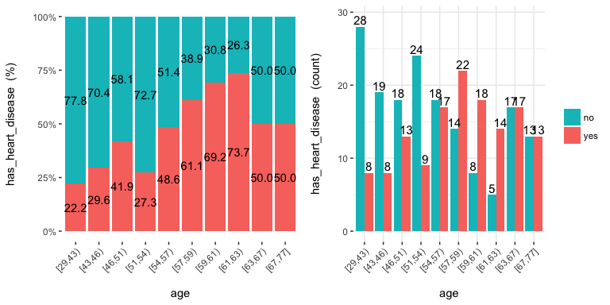

```
## [1] "Plotting transformed variable 'oldpeak' with 'equal_freq', (too many values). Disable with 'auto_binning=FALSE'"
```

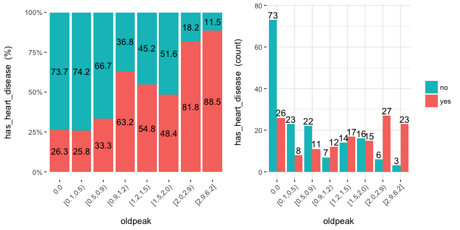

```r
cross_plot(data=heart_disease, input=c("age", "oldpeak"), target="has_heart_disease")
```

🔎 [**Read more here.**](https://livebook.datascienceheroes.com/selecting-best-variables.html#profiling_target_cross_plot)

Notes:

- `auto_binning`: `TRUE` by default, shows the numerical variable as categorical.
- `path_out` indicates the path directory; if it has a value, then the plot is exported in jpeg.
- `input` can be numeric or categoric, and `target` must be a binary (two-class) variable.
- If `input` is empty, then it runs for all variables.

### `plotar`: Boxplot and density histogram between input and target variables

Useful to explain and report if a variable is important or not.

**Boxplot:**

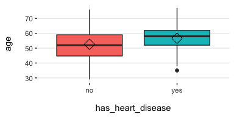

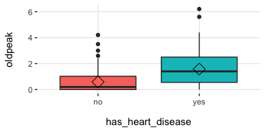

```r
plotar(data=heart_disease, input = c("age", "oldpeak"), target="has_heart_disease", plot_type="boxplot")
```

🔎 [**Read more here.**](https://livebook.datascienceheroes.com/selecting-best-variables.html#target-profiling-using-boxplots)

**Density histograms:**

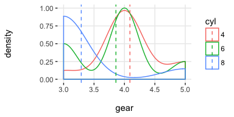

```r
plotar(data=mtcars, input = "gear", target="cyl", plot_type="histdens")
```

🔎 [**Read more here.**](https://livebook.datascienceheroes.com/selecting-best-variables.html#target-profiling-using-density-histograms)

Notes:

- `path_out` indicates the path directory; if it has a value, then the plot is exported in jpeg.
- If `input` is empty, then it runs for all numeric variables (skipping the categorical ones).
- `input` must be numeric and target must be categoric.
- `target` can be multi-class (not only binary).

### `categ_analysis`: Quantitative analysis for binary outcome

Profile a binary target based on a categorical input variable, the representativeness (`perc_rows`) and the accuracy (`perc_target`) for each value of the input variable; for example, the rate of flu infection per country.

```r
df_ca=categ_analysis(data = data_country, input = "country", target = "has_flu")

head(df_ca)
```

```
##          country mean_target sum_target perc_target q_rows perc_rows
## 1       Malaysia        1.00          1       0.012      1     0.001
## 2         Mexico        0.67          2       0.024      3     0.003
## 3       Portugal        0.20          1       0.012      5     0.005
## 4 United Kingdom        0.18          8       0.096     45     0.049
## 5        Uruguay        0.17         11       0.133     63     0.069
## 6         Israel        0.17          1       0.012      6     0.007
```

Note:

- `input` variable must be categorical.
- `target` variable must be binary (two-value).

This function is used to analyze data when we need to reduce variable cardinality in predictive modeling.

🔎 [**Read more here.**](https://livebook.datascienceheroes.com/data-preparation.html#high_cardinality_predictive_modeling)

## Data preparation

### Data discretization

#### `discretize_get_bins` + `discretize_df`: Convert numeric variables to categoric

We need two functions: `discretize_get_bins`, which returns the thresholds for each variable, and then `discretize_df`, which takes the result from the first function and converts the desired variables. The binning criterion is equal frequency.

Example converting only two variables from a dataset.

```r
# Step 1: Getting the thresholds for the desired variables: "max_heart_rate" and "oldpeak"
d_bins=discretize_get_bins(data=heart_disease, input=c("max_heart_rate", "oldpeak"), n_bins=5)
```

```
## [1] "Variables processed: max_heart_rate, oldpeak"
```

```r
# Step 2: Applying the threshold to get the final processed data frame
heart_disease_discretized=discretize_df(data=heart_disease, data_bins=d_bins, stringsAsFactors=T)
```

```
## [1] "Variables processed: max_heart_rate, oldpeak"
```

The following image illustrates the result. Please note that the variable name remains the same.

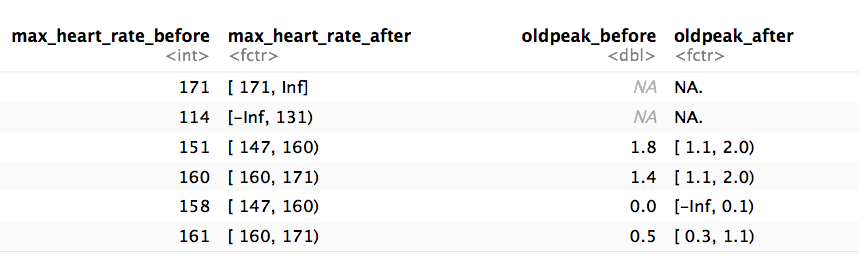

data discretization

Notes:

- This two-step procedure is thought to be used in production with new data.
- Min and max values for each bin will be `-Inf` and `Inf`, respectively.
- A fix in the latest `funModeling` release (1.6.7) may change the output in certain scenarios. Please check the results if using version 1.6.6.

🔎 [**Read more here.**](https://livebook.datascienceheroes.com/data-preparation.html#data-discretization)

### `convert_df_to_categoric`: Convert every column in a data frame to character variables

Binning, or discretization criterion for any numerical variable is equal frequency. Factor variables are directly converted to character variables.

```r
iris_char=convert_df_to_categoric(data = iris, n_bins = 5)
```

```
## [1] "Variables processed: Sepal.Length, Sepal.Width, Petal.Length, Petal.Width"
## [1] "Variables processed: Sepal.Length, Sepal.Width, Petal.Length, Petal.Width"
```

```r
# checking first rows
head(iris_char)
```

```
##   Sepal.Length Sepal.Width Petal.Length Petal.Width Species
## 1  [ 5.1, 5.7) [ 3.5, Inf]  [-Inf, 1.6) [-Inf, 0.3)  setosa
## 2  [-Inf, 5.1) [ 2.8, 3.1)  [-Inf, 1.6) [-Inf, 0.3)  setosa
## 3  [-Inf, 5.1) [ 3.2, 3.5)  [-Inf, 1.6) [-Inf, 0.3)  setosa
## 4  [-Inf, 5.1) [ 3.1, 3.2)  [-Inf, 1.6) [-Inf, 0.3)  setosa
## 5  [-Inf, 5.1) [ 3.5, Inf]  [-Inf, 1.6) [-Inf, 0.3)  setosa
## 6  [ 5.1, 5.7) [ 3.5, Inf]  [ 1.6, 4.0) [ 0.3, 1.2)  setosa
```

### `equal_freq`: Convert numeric variable to categoric

Converts numeric vector into a factor using the equal frequency criterion.

```r
new_age=equal_freq(heart_disease$age, n_bins = 5)

# checking results
Hmisc::describe(new_age)
```

```
## new_age
##        n  missing distinct
##      303        0        5
##
## Value      [29,46) [46,54) [54,59) [59,63) [63,77]
## Frequency       63      64      71      45      60
## Proportion    0.21    0.21    0.23    0.15    0.20
```

🔎 [**Read more here.**](https://livebook.datascienceheroes.com/data-preparation.html#equal-frequency-binning)

Notes:

- Unlike `discretize_get_bins`, this function doesn’t insert `-Inf` and `Inf` as the min and max value respectively.

### `range01`: Scales variable into the 0 to 1 range

Convert a numeric vector into a scale from 0 to 1 with 0 as the minimum and 1 as the maximum.

```r
age_scaled=range01(heart_disease$oldpeak)

# checking results
summary(age_scaled)
```

```
##    Min. 1st Qu.  Median    Mean 3rd Qu.    Max.
##    0.00    0.00    0.13    0.17    0.26    1.00
```

## Outliers data preparation

### `hampel_outlier` and `tukey_outlier`: Gets outliers threshold

Both functions retrieve a two-value vector that indicates the thresholds for which the values are considered as outliers. The functions `tukey_outlier` and `hampel_outlier` are used internally in `prep_outliers`.

**Using Tukey’s method:**

```r
tukey_outlier(heart_disease$resting_blood_pressure)
```

```
## bottom_threshold    top_threshold
##               60              200
```

🔎 [**Read more here.**](https://livebook.datascienceheroes.com/data-preparation.html#detecting-outliers-using-tukey-method)

**Using Hampel’s method:**

```r
hampel_outlier(heart_disease$resting_blood_pressure)
```

```
## bottom_threshold    top_threshold
##               86              174
```

🔎 [**Read more here.**](https://livebook.datascienceheroes.com/data-preparation.html#detecting-outliers-using-hampel-method)

### `prep_outliers`: Prepare outliers in a data frame

Takes a data frame and returns the same data frame plus the transformations specified in the `input` parameter. It also works with a single vector.

```r
# Get threshold according to Hampel's method
hampel_outlier(heart_disease$max_heart_rate)
```

```
## bottom_threshold    top_threshold
##               86              220
```

```r
# Apply function to stop outliers at the threshold values
data_prep=prep_outliers(data = heart_disease, input = c('max_heart_rate','resting_blood_pressure'), method = "hampel", type='stop')
```

```
## bottom_threshold    top_threshold
##               86              220
```

```
## [1] "Before transformation -> Min: 71; Max: 202"
```

```
## [1] "After transformation -> Min: 86.283; Max: 202"
```

Notes:

- `method` can be: `bottom_top`, `tukey` or `hampel`.
- `type` can be: `stop` or `set_na`. If `stop` all values flagged as outliers will be set to the threshold. If `set_na`, then the flagged values will set to `NA`.

🔎 [**Read more here.**](https://livebook.datascienceheroes.com/data-preparation.html#analyze-binary-outcome-vs-categorical-variable)

## Predictive model performance

### `gain_lift`: Gain and lift performance curve

After computing the scores or probabilities for the class we want to predict, we pass it to the `gain_lift` function, which returns a data frame with performance metrics.

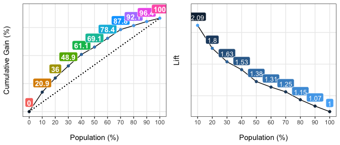

```
##    Population Gain Lift Score.Point
## 1          10   21  2.1        0.82
## 2          20   36  1.8        0.70
## 3          30   49  1.6        0.57
## 4          40   61  1.5        0.49
## 5          50   69  1.4        0.40
## 6          60   78  1.3        0.33
## 7          70   88  1.2        0.29
## 8          80   92  1.1        0.25
## 9          90   96  1.1        0.20
## 10        100  100  1.0        0.12
```

```r
# Create machine learning model and get its scores for positive case
fit_glm=glm(has_heart_disease ~ age + oldpeak, data=heart_disease, family = binomial)
heart_disease$score=predict(fit_glm, newdata=heart_disease, type='response')

# Calculate performance metrics
gain_lift(data=heart_disease, score='score', target='has_heart_disease')
```

🔎 [**Read more here.**](https://livebook.datascienceheroes.com/model-performance.html#gain_and_lift)

- Github repository (report bugs or improvements): https://github.com/pablo14/funModeling
- Creator and mantainer: Pablo Casas https://twitter.com/pabloc_ds